# Machine Learning

Varun Boodram

December 5, 2014

Machine learning comes in two flavours: supervised and unsupervised. The ingredients list for supervised learning is

- an *outcome measurement*, usually quantitative (such as a stock price) or categorical (such as heart attack/no heart attack)
- a set of *features* (such as diet and clinical measurements)
- a *training set* of data, in which we observe the outcome and feature measurements for a set of objects
- a *prediction model*, or learner, which will enable us to predict the outcome for new unseen objects

In unsupervised learning, the outcome measurement are *not* available; these problems instead seek *structure* in the data.

The components of a predictor are

1. a very specific and well-defined *question* (what are you trying to predict, and what are you trying to predict it with?)
2. *input data*
3. measured characteristics or computationally built *features*
4. the *machine learning algorithm*
5. the *estimated parameters* of that algorithm
6. the *application* of those parameters to a new data set, and the *evaluation* of the algorithm on those new data

(Quickly Define Failure And Eject Aircraft)

#### eg: spam detection

1. question: Can quantitiative chararacteristics of emails be use to classify them into spam and ham emails?
2. input data: there is a lot of data avaialble for use, but it may not always be the best; we need to be aware of the limitations of our data.

```r
require(kernlab)
data(spam)
```

3. features: we need to compute characteristics of emails that we receive to use to classify the set of emails

Consider the email

Dear Jeff,  
Can you send me your address so I can send you the invitation?  
Thanks,  
Ben

One characteristic that may allow us to classify this email as spam or ham is the frequency with which certain words appear. Suppose we suspect that the frequency of occurance of the word “your” is associated with an email’s being ham or spam

```r
require(stringr)
# input email for analysis
text<-"Dear Jeff, Can you send me your address so I can send you the invitation? Thanks, Ben"

# find the number of words in the text
words<-unlist(str_split(string = text, pattern = " "))
numwords<-length(words)

# find the number of occurences of "you"
numYours<-length(grep(pattern = "\\byour\\b", x = words))

# compute the ratio of yous to the number of words in the text
numYours/numwords
```

```
## [1] 0.05882353
```

If this ratio is computed for every email that we have, we have a quantitative characteristic that we can use to try to predict.

4. algorithm: Our learning method has to decide which features to use and how. Since we computed a single feature, we only need to worry about how to use it. Before building the algorith, then, we can spend some time *exploring* the feature.

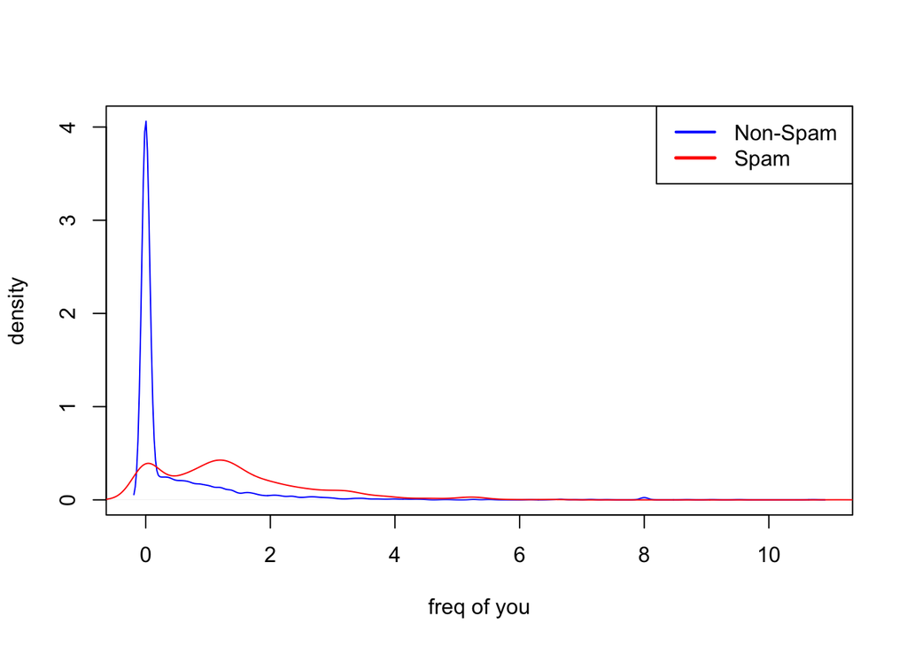

```r
with(spam, {
        plot(density(your[type=="nonspam"]),
             xlab = "freq of you",
             ylab = "density",
             main = "",
             col="blue")
        lines(density(your[type=="spam"]),
              col="red")
        legend("topright",
               lwd=c(2,2.5),
               col = c("blue", "red"),
               legend = c("Non-Spam", "Spam"),
               bty = "y")
})
```

The frequency of occurence of the word “your” among ham emails is small (it peaks near 0), while the frequencies of the word “your” is higher (with a peack at about 1). Thus the algorithm that we may propose for this classification task could be to assign the email to type spam if the number of yours exceeds some number, $C$.

5. parameter estimation: we want to estimate the parameter $C$. The graph below suggests the choice of $C=0.5$.

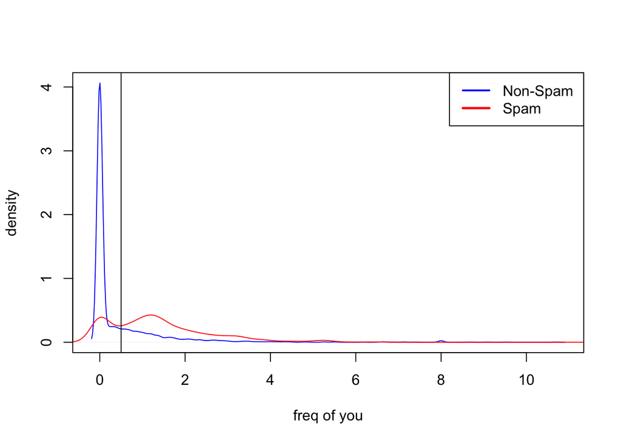

```r
with(spam, {
        plot(density(your[type=="nonspam"]),
             xlab = "freq of you",
             ylab = "density",
             main = "",
             col="blue")
        lines(density(your[type=="spam"]),
              col="red")
        legend("topright",
               lwd=c(2,2.5),
               col = c("blue", "red"),
               legend = c("Non-Spam", "Spam"),
               bty = "y")
        abline(v = 0.5)
})
```

6. application: now we apply the paramter to the new data set

```r
prediction<-ifelse(test = spam$your>0.5, yes = "spam", no = "nonspam")
```

Finally, we want to see how well the algorithm did at correctly classifying emails.

```r
table(prediction, spam$type)
```

```
##
## prediction nonspam spam
##    nonspam    2112  468
##    spam        676 1345
```

```r
table(prediction, spam$type)/length(spam$type)*100
```

```
##
## prediction  nonspam     spam
##    nonspam 45.90306 10.17170
##    spam    14.69246 29.23278
```

```r
46+29
```

```
## [1] 75
```

#### the algorithm is a *function*

There is a set of variables in the above procedure that are *inputs* and another set that are *outputs*. These are related by a function.

$G=f(X) = \begin{cases} \text{nonspam} & \text{if } X< 0.5 \\ \text{spam} & \text{, else } \end{cases}$

When the output is qualitative, it is denoted by $G$, and these are called *classification* problems; quantitative outputs are denoted by $Y$, and these are called *regression* problems. In the above example, $X$ was a one dimensional vector, but it doesn’t have to be; if $X$ is a multidimensional vector, the $i$th observed value of $X$ is $x_i$. The learning task is as follows: given the value of an input vector $X$, make a good prediction of the output $Y$, denoted by $\hat{Y}$. If $Y$ takes values in $\mathbb{R}$ then so should $\hat{Y}$; likewise for categorical outputs, $\hat{G}$ should take values in the same set $G$ associated with $G$